# Mikrostruktura rynków finansowych - projekt nr 2

Tymoteusz Hanusiak, Piotr Juruś

2026-02-06

```r
library(knitr)
opts_chunk$set(message = FALSE, warning = FALSE)
```

```r
library(knitr)
library(readr)
library(dplyr)
library(lubridate)
library(stringr)
library(purrr)
library(tidyr)
library(moments)
library(ggplot2)
library(rugarch)
```

# Czyszczenie danych

```r
# funkcja czyszcząca wstępnie dane z obydwu plików

prepare_intraday_data <- function(path) {

  df <- read.csv2(path, stringsAsFactors = FALSE)

  df$daty <- as.Date(as.character(df$daty), format = "%Y%m%d")

  godz_char <- sprintf("%06d", as.integer(df$godz))

  df$datetime <- as.POSIXct( paste( df$daty,
      paste0(
        substr(godz_char, 1, 2), ":",
        substr(godz_char, 3, 4), ":",
        substr(godz_char, 5, 6)
      )
    ), format = "%Y-%m-%d %H:%M:%S", tz = "UTC")

  df$cena <- as.numeric(df$cena)
  df$vol  <- as.numeric(df$vol)

  df <- df[ format(df$datetime, "%H:%M:%S") >= "09:00:00" & format(df$datetime, "%H:%M:%S") <= "16:50:00",]

  df <- df[order(df$datetime), ]

  # usunięcie zbędnej kolumny; reset nazwy wierszy po filtracji
  df$godz <- NULL
  rownames(df) <- NULL

  return(df)
}
```

```r
dane_spolkaI <- prepare_intraday_data("spolkaI.csv")
dane_spolkaJ <-  prepare_intraday_data("spolkaJ.csv")
```

```r
head(dane_spolkaI)
```

```
        daty  cena vol            datetime
1 2018-01-03 101.4  27 2018-01-03 09:00:00
2 2018-01-03 101.4   1 2018-01-03 09:00:00
3 2018-01-03 101.4  56 2018-01-03 09:00:00
4 2018-01-03 101.4   1 2018-01-03 09:00:00
5 2018-01-03 101.4   2 2018-01-03 09:00:00
6 2018-01-03 101.4  10 2018-01-03 09:00:00
```

```r
head(dane_spolkaJ)
```

```
        daty cena  vol            datetime
1 2018-01-03 46.3   45 2018-01-03 09:00:00
2 2018-01-03 46.3    1 2018-01-03 09:00:00
3 2018-01-03 46.3 2000 2018-01-03 09:00:00
4 2018-01-03 46.3  843 2018-01-03 09:00:00
5 2018-01-03 46.3   22 2018-01-03 09:00:00
6 2018-01-03 46.3   24 2018-01-03 09:00:00
```

# Transakcyjne czasy trwania

- Funkcja nie uwzględnia czasów trwania overnight.

```r
#

czasy_trwania <- function(df) {

  # agregacja obserwacji o tym samym znaczniku czasu
  agg <- aggregate( cbind(cena, vol) ~ datetime + daty, data = df, FUN = function(x) x)

  agg$cena <- mapply( function(p, v) sum(p * v) / sum(v), agg$cena, agg$vol)

  agg$vol <- sapply(agg$vol, sum)

  # zabezpiczenie kolejności
  df <- agg[order(agg$datetime), ]

  # czas trwania
  df$duration <- as.numeric(df$datetime - dplyr::lag(df$datetime))

  # RESET PRZY ZMIANIE DNIA
  idx_new_day <- df$daty != dplyr::lag(df$daty) # reset duration przy przejściu na nowy dzień
  df$duration[idx_new_day] <- 0

  # usuwamy NA (pierwsza obserwacja w całej próbie)
  df <- df[!is.na(df$duration), ]

  rownames(df) <- NULL
  return(df)
}
```

```r
dane_spolkaI <- czasy_trwania(dane_spolkaI)

dane_spolkaJ <- czasy_trwania(dane_spolkaJ)
```

```r
head(dane_spolkaI)
```

```
             datetime       daty     cena vol duration
1 2018-01-03 09:01:01 2018-01-03 101.4000  48       61
2 2018-01-03 09:01:21 2018-01-03 101.4000 100       20
3 2018-01-03 09:01:23 2018-01-03 101.4472 352        2
4 2018-01-03 09:01:34 2018-01-03 101.4000  75       11
5 2018-01-03 09:01:46 2018-01-03 101.5682 471       12
6 2018-01-03 09:01:49 2018-01-03 101.7000 127        3
```

```r
head(dane_spolkaJ)
```

```
             datetime       daty     cena  vol duration
1 2018-01-03 09:00:02 2018-01-03 46.44000  871        2
2 2018-01-03 09:00:07 2018-01-03 46.44000  393        5
3 2018-01-03 09:00:16 2018-01-03 46.35000  651        9
4 2018-01-03 09:00:24 2018-01-03 46.42688 1524        8
5 2018-01-03 09:00:26 2018-01-03 46.46000  389        2
6 2018-01-03 09:00:33 2018-01-03 46.44000   82        7
```

# Statystyki opisowe

```r
opisowe <- function(df,nazwa) {

  d <- df$duration

  data.frame(Spolka= nazwa, srednia= mean(d),mediana= median(d),std= sd(d), Min= min(d),Max= max(d),WZ= sd(d) / mean(d)  *100)
}
```

## Wyniki

```r
stats_A <- opisowe(dane_spolkaI, "Spolka I")
stats_B <- opisowe(dane_spolkaJ, "Spolka J")

stats_table <- rbind(stats_A, stats_B)

stats_table
```

```
    Spolka  srednia mediana      std Min  Max       WZ
1 Spolka I 17.48837       5 32.36019   0 1061 185.0384
2 Spolka J 17.76937       5 33.49976   0 1467 188.5253
```

- Na pierwszy rzut oka można zauważyć, że podstawowe statystyki opisowe transakcyjnych czasów trwania dla obu spółek są bardzo zbliżone. Zarówno średnia, jak i mediana przyjmują niemal identyczne wartości, co sugeruje, że typowy czas trwania transakcji jest porównywalny dla obu analizowanych spółek.
- Istotną różnicę pomiędzy spółkami stanowią wartości maksymalne. Dla spółki J maksymalny czas trwania jest wyraźnie wyższy niż dla spółki I (różnica około 406 sekund), co wskazuje na wystąpienie pojedynczych, wyjątkowo długich okresów bez zmiany ceny. Jednocześnie w obu spółkach obserwowane są bardzo wysokie wartości maksymalne, przekraczające 1000 sekund, co potwierdza obecność rzadkich obserwacji ekstremalnych w rozkładzie czasów trwania.
- Tak długie przerwy mogą być związane z chwilowym spadkiem aktywności inwestorów, zwiększoną niepewnością rynkową lub oczekiwaniem na istotne informacje rynkowe, podczas których uczestnicy rynku wstrzymują się z podejmowaniem decyzji transakcyjnych.
- Różnica rzędu 406 sekund pomiędzy spółkami może wynikać z odmiennych charakterystyk płynności, struktury uczestników rynku lub zróżnicowanych strategii inwestycyjnych dominujących dla danej spółki, co prowadzi do większej podatności spółki J na występowanie ekstremalnie długich okresów bez transakcji.
- Współczynniki zmienności dla obu spółek są do siebie bardzo zbliżone, przyjmują wartości na poziomie około 188%. Tak wysoka wartość współczynnika zmienności oznacza, że odchylenie standardowe jest niemal dwukrotnie większe od wartości średniej, co świadczy o silnej dyspersji danych oraz obecności grubych ogonów w rozkładzie czasów trwania.

# Przekrojowe średnie

```r
intraday_seasonality_5min <- function(df) {

  # wydzielenie na 5 minutowe biny
  df$time_bin <- sprintf( "%02d:%02d", as.integer(format(df$datetime, "%H")), as.integer(format(df$datetime, "%M")) %/% 5 * 5)

  # AGREGACJA PO ALL DNIACH
  seasonality <- data.frame( time_bin = sort(unique(df$time_bin)), mean_duration = as.numeric( tapply(df$duration, df$time_bin, base::mean) ))
  seasonality$time_plot <- as.POSIXct( paste("1970-01-01", seasonality$time_bin), tz = "UTC")

  return(seasonality)
}
```

```r
season_I <- intraday_seasonality_5min(dane_spolkaI)
season_J <- intraday_seasonality_5min(dane_spolkaJ)

season_I$Spolka <- "Spolka I"
season_J$Spolka <- "Spolka J"

season_all <- rbind(season_I, season_J)
```

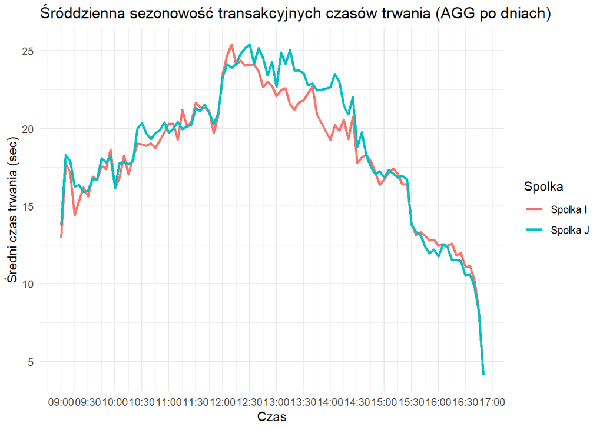

```r
library(ggplot2)

ggplot(season_all,
       aes(x = time_plot, y = mean_duration, color = Spolka)) +
  geom_line(linewidth = 1) +
  scale_x_datetime(date_labels = "%H:%M", date_breaks = "30 min") +
  labs(
    title = "Śróddzienna sezonowość transakcyjnych czasów trwania (AGG po dniach)",
    x = "Czas",
    y = "Średni czas trwania (sec)"
  ) +
  theme_minimal()
```

- Średnie czasy trwania charaketryzują się sezonowścia so widać po U-kształtym wykresie.
- Na poczaktu i na końcu sesji średnio często zawierane są transkacje co widać po niskich wartościach średnicj czasów trwania.
- Natomiast podczas środkowej fazy sesji transakcje średnio cechują się zdecydowanie mniejszą częśtotliwościa niż na poczaktu i na końcu sesji.,
- Zauważalne jest przełamanie w połowie sesji, gdy zamiast czasy trwania rosnąc zaczynają (im bliżej końca sesji) spadać.
- Zdecydowanie z większą średnią częstotliwością zawierane są transakcję na koniec sesji, ponieważ średnia wynosi około 5 sekund a na początku około 13/14 sekund.
- Średnie czasy trwania między spółkami nie róznią się znacząco . Poza jedną fazą sesji, występują pojedyńcze róznice gdzie spółka np J ma większe czasy trwania, a w innych spółka I.
- Najmniejsze średnie rożnice występują na początku i na końcu sesji.
- Natomiast w okoliach punktu przełamania gdzie średnie czasy trwania zaczynają maleć, różnica jest już większa ( godziny 12:15 a 14:30 ). Spólka I w tej fazie cechuję się średnio mniejszym czasem trwania niż spółka J. Co oznacza ze w tej fazie transakcję są zawierane średnio częsciej.

```r
season_all
```

```
    time_bin mean_duration           time_plot   Spolka
1      09:00     12.956374 1970-01-01 09:00:00 Spolka I
2      09:05     17.760522 1970-01-01 09:05:00 Spolka I
3      09:10     17.176661 1970-01-01 09:10:00 Spolka I
4      09:15     14.420166 1970-01-01 09:15:00 Spolka I
5      09:20     15.362041 1970-01-01 09:20:00 Spolka I
6      09:25     16.208460 1970-01-01 09:25:00 Spolka I
7      09:30     15.636781 1970-01-01 09:30:00 Spolka I
8      09:35     16.906544 1970-01-01 09:35:00 Spolka I
9      09:40     16.694545 1970-01-01 09:40:00 Spolka I
10     09:45     17.593108 1970-01-01 09:45:00 Spolka I
11     09:50     17.404270 1970-01-01 09:50:00 Spolka I
12     09:55     18.642397 1970-01-01 09:55:00 Spolka I
13     10:00     16.140804 1970-01-01 10:00:00 Spolka I
14     10:05     16.843962 1970-01-01 10:05:00 Spolka I
```

[output cut: 176 more lines]

# Usuwanie śródziennej zmienności

```r
prepare_diurnal_bins <- function(df) {

  df$time_bin <- sprintf("%02d:%02d", as.integer(format(df$datetime, "%H")), as.integer(format(df$datetime, "%M")) %/% 5 * 5 )

  df$dow <- weekdays(df$daty)

  return(df)
}
```

```r
spolkaI <- prepare_diurnal_bins(dane_spolkaI)

spolkaJ <- prepare_diurnal_bins(dane_spolkaJ)
```

```r
head(spolkaI)
```

```
             datetime       daty     cena vol duration time_bin   dow
1 2018-01-03 09:01:01 2018-01-03 101.4000  48       61    09:00 środa
2 2018-01-03 09:01:21 2018-01-03 101.4000 100       20    09:00 środa
3 2018-01-03 09:01:23 2018-01-03 101.4472 352        2    09:00 środa
4 2018-01-03 09:01:34 2018-01-03 101.4000  75       11    09:00 środa
5 2018-01-03 09:01:46 2018-01-03 101.5682 471       12    09:00 środa
6 2018-01-03 09:01:49 2018-01-03 101.7000 127        3    09:00 środa
```

```r
library(ACDm)



remove_diurnal_seasonality <- function(df) {

  # funkcja nie przyjmuje ujemnych wartosci i 0
  df <- df[df$duration > 0, ]

  durData <- data.frame(durations = as.numeric(df$duration),time= df$datetime)

  adj <- diurnalAdj(dur= durData, method= "FFF", aggregation = "weekdays",Q = 3)

  df$duration_adj <- adj$adjDur
  df$seasonality  <- df$duration / df$duration_adj

  return(df)
}
```

```r
spolkaI <- remove_diurnal_seasonality(spolkaI)
```

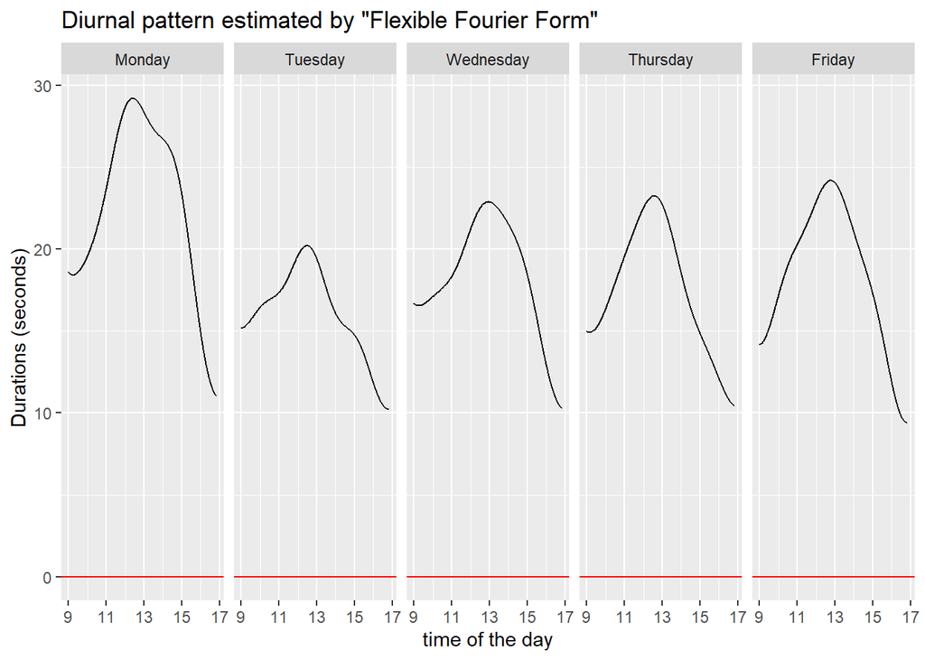

```r
spolkaJ <- remove_diurnal_seasonality(spolkaJ)
```

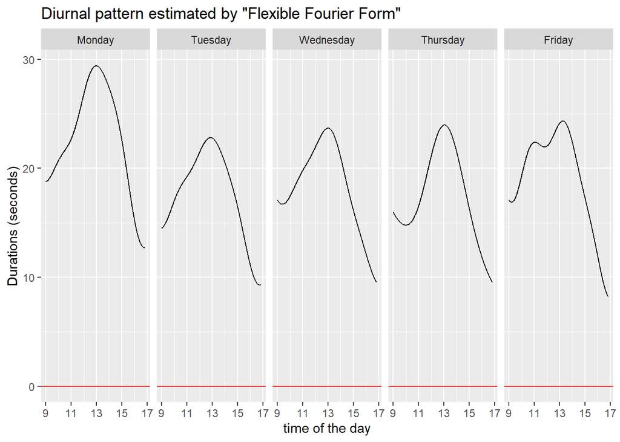

W obu przypadkach widoczny jest wyraźny śróddzienny wzorzec sezonowy czasów trwania transakcji. Czasy trwania są relatywnie krótsze na początku oraz pod koniec sesji giełdowej, natomiast osiągają najwyższe wartości w środkowej części dnia. Oznacza to większą intensywność transakcji w godzinach otwarcia i zamknięcia rynku oraz niższą aktywność handlową w trakcie sesji.

Dla spółki J oszacowane czasy trwania transakcji są przeciętnie wyższe w porównaniu do spółki I. Różnica ta jest szczególnie widoczna w przypadku wtorków, natomiast w pozostałych dniach tygodnia czasy trwania dla spółki J są nieznacznie wyższe niż dla spółki I.

W przypadku piątku obserwowany jest bimodalny rozkład składowej sezonowej, charakteryzujący się występowaniem dwóch lokalnych maksimów czasów trwania transakcji, co może wskazywać na zróżnicowaną aktywność inwestorów w różnych fazach sesji.

Dodatkowo, po jak i przed punktem przełamania (tj. momencie, w którym funkcja sezonowa zaczyna maleć), spółka J charakteryzuje się bardziej gładkim i stopniowym spadkiem czasów trwania w porównaniu do spółki I. Ogólnie można stwierdzić, że zarówno wzrosty, jak i spadki składowej sezonowej są dla spółki J bardziej wygładzone, podczas gdy dla spółki I obserwuje się bardziej nieregularne zmiany na przykład dla poniedziałku i wtorku.

```r
cross_sectional_mean_adj <- function(df, spolka_name = NULL) {

  out <- aggregate( duration_adj ~ time_bin, data = df,FUN = function(x) mean(x, na.rm = TRUE))

  out$time_plot <- as.POSIXct( paste("1970-01-01", out$time_bin),tz = "UTC")

  out <- out[order(out$time_plot), ]
  rownames(out) <- NULL

  if (!is.null(spolka_name)) {
    out$Spolka <- spolka_name
  }

  return(out)
}
```

```r
mean_I <- cross_sectional_mean_adj(spolkaI, "Spółka I")
mean_J <- cross_sectional_mean_adj(spolkaJ, "Spółka J")

mean_all <- rbind(mean_I, mean_J)
```

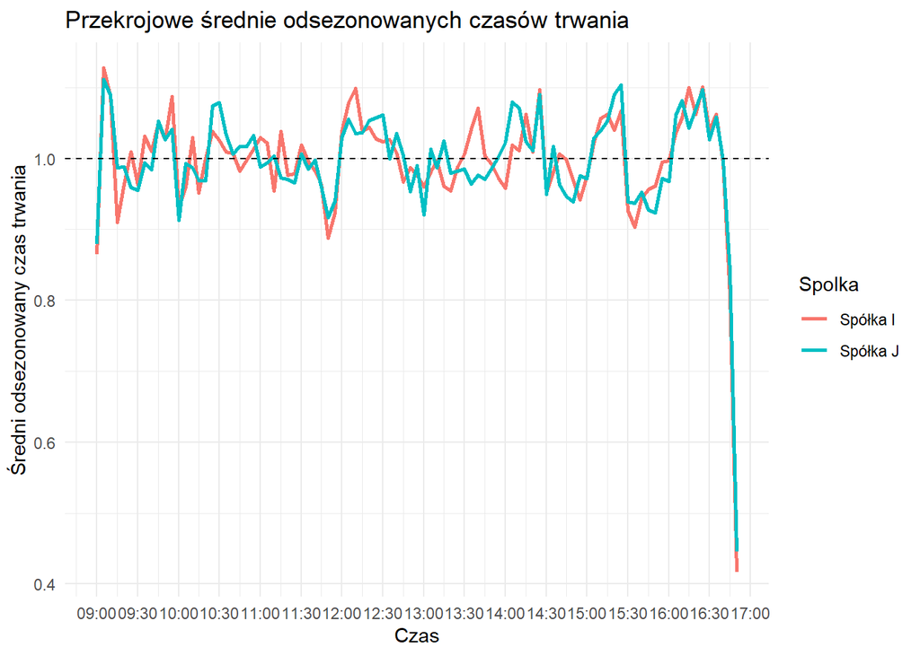

```r
ggplot(mean_all,
       aes(x = time_plot, y = duration_adj, color = Spolka)) +
  geom_line(linewidth = 1) +
  geom_hline(yintercept = 1, linetype = "dashed") +
  scale_x_datetime(date_labels = "%H:%M", date_breaks = "30 min") +
  labs(
    title = "Przekrojowe średnie odsezonowanych czasów trwania",
    x = "Czas",
    y = "Średni odsezonowany czas trwania"
  ) +
  theme_minimal()
```

- Po usunięciu śróddziennej sezonowości widoczne jest istotne spłaszczenie przebiegu średnich czasów trwania.
- W przeciwieństwie do nieodsezonowanych danych, w których obecny był wyraźny śróddzienny wzorzec sezonowy (z maksimum w środkowej części sesji oraz minimami na jej początku i końcu), po modyfikacji wartości przekrojowych średnich oscylują wokół poziomu 1, bez systematycznego trendu zależnego od pory dnia. Oznacza to, że śróddzienna sezonowość została w dużej mierze skutecznie usunięta.
- Dla obu spółek przebiegi odsezonowanych czasów trwania są bardzo zbliżone i charakteryzują się jedynie niewielkimi, losowymi fluktuacjami, które nie wykazują regularnej struktury w czasie
- Pomimo usunięcia śróddziennej sezonowości, na początku oraz na końcu sesji giełdowej nadal widoczne są odchylenia od wartosci 1, których FFF nie uchwyciła.

# Cenowe czasy trwania

## Funkcja do agregacji transakcji i konstrukcji cenowych czasów trwania

```r
price_durations <- function(df, p0) {

  ## agg transakcje, same time
  agg <- aggregate( cbind(cena, vol) ~ datetime + daty, data = df,
    FUN = function(x) x
  )

  agg$cena <- mapply( function(p, v) sum(p * v) / sum(v), agg$cena, agg$vol)

  agg$vol <- sapply(agg$vol, sum)

  agg <- agg[order(agg$datetime), ]

   agg <- agg[ format(agg$datetime, "%H:%M:%S") >= "09:00:00" & format(agg$datetime, "%H:%M:%S") <= "16:50:00",]

  durations  <- numeric(0)

  last_time  <- agg$datetime[1]
  last_price <- agg$cena[1]
  last_date  <- agg$daty[1]

  for (i in 2:nrow(agg)) {

    # reset przy zmianie dnia aby unikac przejscia overnight
    if (agg$daty[i] != last_date) {
      last_time  <- agg$datetime[i]
      last_price <- agg$cena[i]
      last_date  <- agg$daty[i]
      next
    }

    # przekroczenie progu cenowego
    if (abs(agg$cena[i] - last_price) >= p0) {

      durations <- c( durations, as.numeric(agg$datetime[i] - last_time))

      last_time  <- agg$datetime[i]
      last_price <- agg$cena[i]
    }
  }

  return(durations)
}
```

```r
head(dane_spolkaI)
```

```
             datetime       daty     cena vol duration
1 2018-01-03 09:01:01 2018-01-03 101.4000  48       61
2 2018-01-03 09:01:21 2018-01-03 101.4000 100       20
3 2018-01-03 09:01:23 2018-01-03 101.4472 352        2
4 2018-01-03 09:01:34 2018-01-03 101.4000  75       11
5 2018-01-03 09:01:46 2018-01-03 101.5682 471       12
6 2018-01-03 09:01:49 2018-01-03 101.7000 127        3
```

```r
p_levels <- c(0.01, 0.05, 0.10) # progi

price_I <- lapply(p_levels, function(p) price_durations(dane_spolkaI, p)) # policzone dla spolki I

names(price_I) <- c("jeden_gr", "piec_gr", "dzies_gr")


price_J <- lapply(p_levels, function(p) price_durations(dane_spolkaJ, p)) # policzone dla spolki J

names(price_J) <- c("jeden_gr", "piec_gr", "dzies_gr")
```

## Statystyki opisowe

```r
cenowe_stats <- function(x) {
  data.frame(średnia= mean(x),mediana= median(x),
    std= sd(x),Min= min(x),Max= max(x),WZ= (sd(x) / mean(x)) *100

  )
}
```

```r
stats_I <- cenowe_stats(price_I$piec_gr)
stats_J <- cenowe_stats(price_J$piec_gr)

stats_I$Spolka <- "Spółka I"
stats_J$Spolka <- "Spółka J"

stats_all <- rbind(stats_I, stats_J)

stats_all
```

```
   średnia  mediana      std Min      Max       WZ   Spolka
1 13.29037 6.000000 15.23233   1 59.00000 114.6119 Spółka I
2 12.00901 5.666667 14.11513   1 59.26667 117.5378 Spółka J
```

## Przekrojowe srednie

```r
cross_sectional_price_duration <- function(durations, times, p_label, spolka_name) {

  df <- data.frame(time = times, duration = durations)

  # 5-minutowy bin
  df$time_bin <- sprintf("%02d:%02d", as.integer(format(df$time, "%H")),(as.integer(format(df$time, "%M")) %/% 5) * 5)

  # agregacja
  out <- aggregate(duration ~ time_bin,data = df,FUN = base::mean)

  # dodanie czasu (artificial)
  out$time_plot <- as.POSIXct( paste("1970-01-01", out$time_bin),tz = "UTC")

  out$p0 <- p_label
  out$Spolka <- spolka_name

  out <- out[order(out$time_plot), ]

  rownames(out) <- NULL

  return(out)
}
```

```r
price_durations_with_time <- function(df, p0) {

  # agregaja po wolumneie jak ten sam moment transakcji
  agg<- aggregate( cbind(cena, vol) ~ datetime + daty, data = df, FUN = function(x) x)

  agg$cena<- mapply( function(p, v) sum(p * v) / sum(v), agg$cena, agg$vol)

  agg$vol<- sapply(agg$vol, sum)

  agg<- agg[order(agg$datetime), ]

  # in case of jakby bin wyszedl zle, dodatkowa flaga
  agg <- agg[ format(agg$datetime, "%H:%M:%S") >= "09:00:00" & format(agg$datetime, "%H:%M:%S") <= "16:50:00",]

  durations <- numeric(0)

  times<- as.POSIXct(character(0), tz = "UTC")

  last_time <- agg$datetime[1]

  last_price<- agg$cena[1]

  last_date <- agg$daty[1]

   for (i in 2:nrow(agg)) {

    # new day to resetujemy zeby nie brac pod uwage overnight czasow trwania
    if (agg$daty[i] != last_date) {
      last_time  <- agg$datetime[i]
      last_price <- agg$cena[i]
      last_date  <- agg$daty[i]
      next
    }

    # przekroczenie progu
    if (abs(agg$cena[i] - last_price) >= p0) {

      durations <- c( durations, as.numeric(difftime(agg$datetime[i], last_time, units = "secs")))

      times <- c(times, agg$datetime[i])

      last_time  <- agg$datetime[i]
      last_price <- agg$cena[i]
    }
  }

  return(list( durations = durations,times= times))
}
```

## spółka I

```r
# Spółka I
pd_I_1 <- price_durations_with_time(dane_spolkaI, 0.01)
pd_I_5 <- price_durations_with_time(dane_spolkaI, 0.05)
```

```r
cs_I_1 <- cross_sectional_price_duration( pd_I_1$durations, pd_I_1$times, "1 gr", "Spółka I" )

cs_I_5 <- cross_sectional_price_duration( pd_I_5$durations, pd_I_5$times, "5 gr", "Spółka I" )

plot_I <- rbind(cs_I_1, cs_I_5)
```

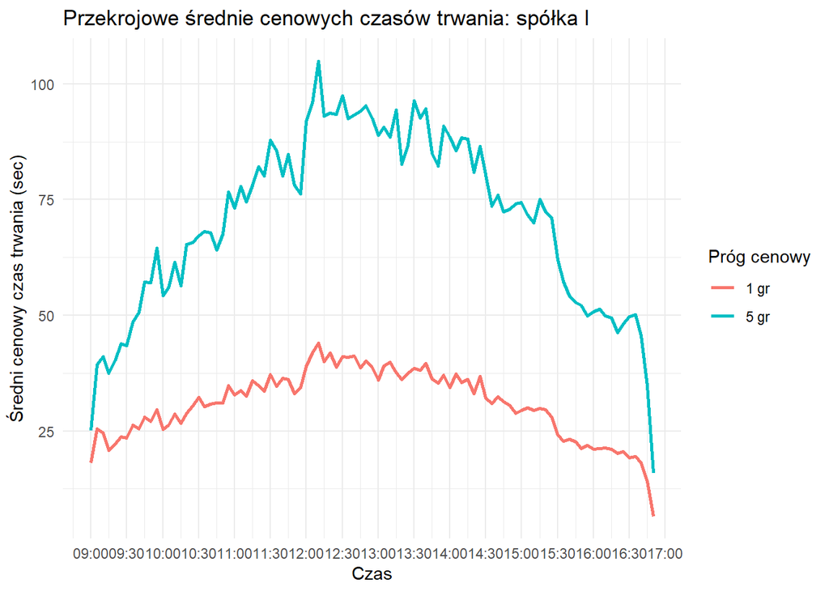

```r
ggplot(plot_I,
       aes(x = time_plot, y = duration, color = p0)) +
  geom_line(linewidth = 1) +
  scale_x_datetime(date_labels = "%H:%M", date_breaks = "30 min") +
  labs(
    title = "Przekrojowe średnie cenowych czasów trwania: spółka I",
    x = "Czas",
    y = "Średni cenowy czas trwania (sec)",
    color = "Próg cenowy"
  ) +
  theme_minimal()
```

- Średnie czasy trwania dla progu 5 groszy są w całym przebiegu sesji wyraźnie wyższe niż dla progu 1 grosza, co jest zgodne z intuicją osiągnięcie większej zmiany ceny wymaga przeciętnie dłuższego czasu. Różnica pomiędzy progami jest szczególnie widoczna w środkowej części sesji, gdzie aktywność handlowa jest relatywnie niższa.
- Dodatkowo na uzyskany przebieg wpływa skala cenowa analizowanej spółki. Przy poziomach notowań rzędu 80–100 jednostek (Spółka I), zmiana ceny o 5 groszy stanowi relatywnie niewielką zmianę procentową, co sprzyja częstszemu osiąganiu wyższego progu cenowego w porównaniu do spółek o niższych cenach nominalnych.
- Podobnie jak w przypadku transakcyjnych czasów trwania, można dostrzec wyraźną śróddzienną sezonowosć o kształcie litery U. Średnie czasy trwania są najkrótsze na początku i na końcu sesji giełdowej, natomiast osiągają najwyższe wartości w środkowej części dnia, co odzwierciedla zmiany intensywności handlu w trakcie sesji.
- Dodatkowo podobnie jak w przypadku transakcyjnych czasów trwania średni cenowy czas trwania jest wyższy na otwarciu niż na zamknięciu, co pokazuję większa intensywność handlu na koniec sesji niż na poczatku.
- Podsumowując, wykresy potwierdzają, że cenowe czasy trwania są silnie zależne zarówno od wielkości progu cenowego, jak i pory dnia.

## spółka J

```r
pd_J_1 <- price_durations_with_time(dane_spolkaJ, 0.01)
pd_J_5 <- price_durations_with_time(dane_spolkaJ, 0.05)
```

```r
cs_J_1 <- cross_sectional_price_duration( pd_J_1$durations, pd_J_1$times, "1 gr", "Spółka I")

cs_J_5 <- cross_sectional_price_duration(pd_J_5$durations, pd_J_5$times, "5 gr", "Spółka I")

plot_J <- rbind(cs_J_1, cs_J_5)
```

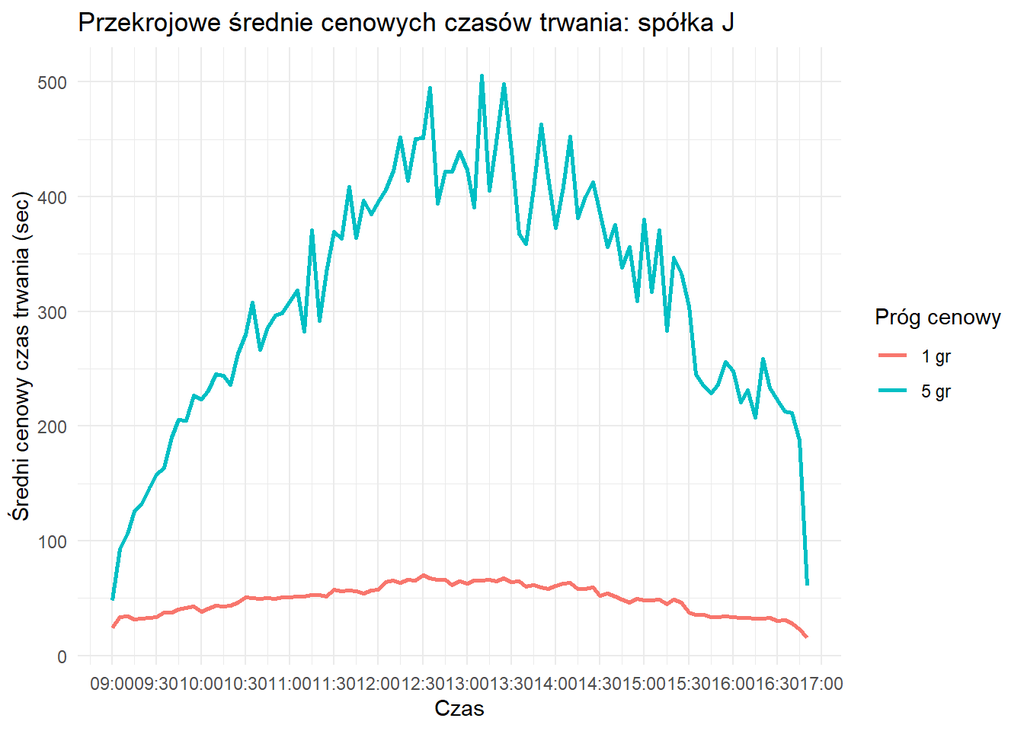

```r
ggplot(plot_J,
       aes(x = time_plot, y = duration, color = p0)) +
  geom_line(linewidth = 1) +
  scale_x_datetime(date_labels = "%H:%M", date_breaks = "30 min") +
  labs(
    title = "Przekrojowe średnie cenowych czasów trwania: spółka J",
    x = "Czas",
    y = "Średni cenowy czas trwania (sec)",
    color = "Próg cenowy"
  ) +
  theme_minimal()
```